# Lab 4 Solutions

## Exercise 1

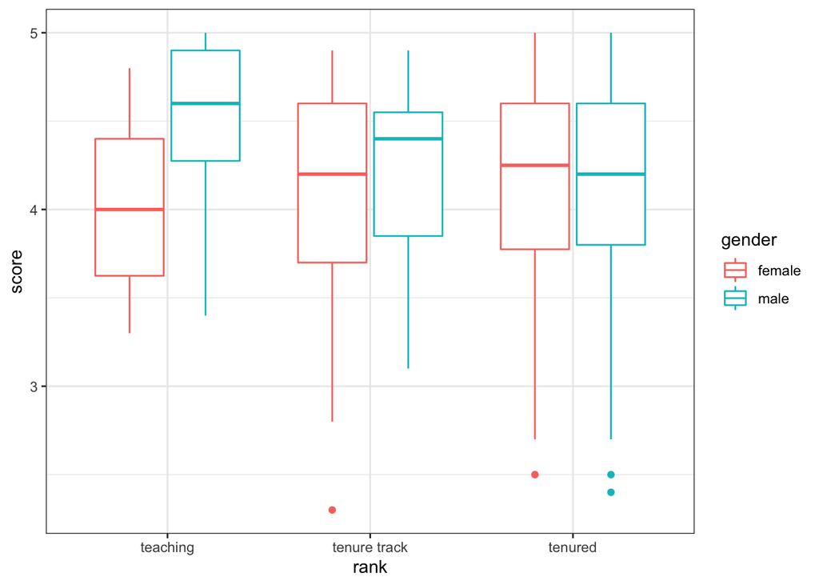

```r
evals %>%
  ggplot(aes(x = rank, y = score, color = gender)) +
  geom_boxplot() +
  theme_bw()
```

For male professors, it looks like teaching professors get higher scores than tenure-track and tenured professors. For female professors, on the other hand, it looks like teaching professors get lower scores than tenure-track and tenured professors. Female teaching and tenure-track professors appear to get lower scores than their male counterparts, whereas tenured professors from both genders seem to score the same.

## Exercise 2

```r
eval_lm1 <- lm(score ~ rank, data = evals)
summary(eval_lm1)
```

```
##
## Call:
## lm(formula = score ~ rank, data = evals)
##
## Residuals:
##     Min      1Q  Median      3Q     Max
## -1.8546 -0.3391  0.1157  0.4305  0.8609
##
## Coefficients:
##                  Estimate Std. Error t value Pr(>|t|)
## (Intercept)       4.28431    0.05365  79.853   <2e-16 ***
## ranktenure track -0.12968    0.07482  -1.733   0.0837 .
## ranktenured      -0.14518    0.06355  -2.284   0.0228 *
## ---
## Signif. codes:  0 '***' 0.001 '**' 0.01 '*' 0.05 '.' 0.1 ' ' 1
##
## Residual standard error: 0.5419 on 460 degrees of freedom
## Multiple R-squared:  0.01163,    Adjusted R-squared:  0.007332
## F-statistic: 2.706 on 2 and 460 DF,  p-value: 0.06786
```

$$\widehat{\text{Score}} = 4.28 - 0.13 \text{IsTenureTrack} - 0.15 \text{IsTenured}$$

$R^2_{adj} = 0.0073$ (we explain very little variability in score by differences in rank)

## Exercise 3

Teaching professors: the average score is 4.28 (the intercept in our fitted model)

Tenure track professors: the average score is $4.28 - 0.13 = 4.15$

Tenured professors: the average score is $4.28 - 0.15 = 4.13$

## Exercise 4

```r
eval_lm2 <- lm(score ~ rank + gender, data = evals)
summary(eval_lm2)
```

```
##
## Call:
## lm(formula = score ~ rank + gender, data = evals)
##
## Residuals:
##     Min      1Q  Median      3Q     Max
## -1.7941 -0.3418  0.1011  0.4105  0.9781
##
## Coefficients:
##                  Estimate Std. Error t value Pr(>|t|)
## (Intercept)       4.19887    0.05954  70.520  < 2e-16 ***
## ranktenure track -0.10476    0.07450  -1.406  0.16033
## ranktenured      -0.17699    0.06373  -2.777  0.00570 **
## gendermale        0.16760    0.05272   3.179  0.00158 **
## ---
## Signif. codes:  0 '***' 0.001 '**' 0.01 '*' 0.05 '.' 0.1 ' ' 1
##
## Residual standard error: 0.5366 on 459 degrees of freedom
## Multiple R-squared:  0.03292,    Adjusted R-squared:  0.0266
## F-statistic: 5.208 on 3 and 459 DF,  p-value: 0.001519
```

$$\widehat{\text{Score}} = 4.20 - 0.10 \ \text{IsTenureTrack} - 0.18 \ \text{IsTenured} + 0.17 \ \text{IsMale}$$

$R^2_{adj} = 0.0266$ (we explain a little more variability in score by adding gender to the model)

## Exercise 5

The predicted average score for male teaching professors is $4.2 + 0.17 = 4.37$

## Exercise 6

On average, male professors score 0.17 points higher than female professors of the same rank.

## Exercise 7

No – the plot from exercise 1 suggests that we need an interaction. There is a noticeable difference in scores for male and female teaching professors, but male and female tenured professors have very similar scores.

## Exercise 8

```r
eval_lm3 <- lm(score ~ rank*gender, data = evals)
summary(eval_lm3)
```

```
##
## Call:
## lm(formula = score ~ rank * gender, data = evals)
##
## Residuals:
##      Min       1Q   Median       3Q      Max
## -1.79710 -0.34520  0.07885  0.37885  0.87500
##
## Coefficients:
##                             Estimate Std. Error t value Pr(>|t|)
## (Intercept)                  4.03800    0.07498  53.855  < 2e-16 ***
## ranktenure track             0.05910    0.09847   0.600 0.548660
## ranktenured                  0.08700    0.09654   0.901 0.367982
## gendermale                   0.48315    0.10501   4.601 5.46e-06 ***
## ranktenure track:gendermale -0.32385    0.14936  -2.168 0.030660 *
## ranktenured:gendermale      -0.46296    0.12773  -3.625 0.000322 ***
## ---
## Signif. codes:  0 '***' 0.001 '**' 0.01 '*' 0.05 '.' 0.1 ' ' 1
##
## Residual standard error: 0.5302 on 457 degrees of freedom
## Multiple R-squared:  0.05996,    Adjusted R-squared:  0.04967
## F-statistic:  5.83 on 5 and 457 DF,  p-value: 3.11e-05
```

$$\widehat{\text{Score}} = 4.038 + 0.059 \ \text{IsTenureTrack} + 0.087 \ \text{IsTenured} + 0.483 \ \text{IsMale} - 0.324 \ \text{IsTenureTrack} \cdot \text{IsMale} - 0.463 \ \text{IsTenured} \cdot \text{IsMale}$$
$R^2_{adj} = 0.050$

## Exercise 9

The estimated average score for male teaching professors is $4.038 + 0.483 = 4.521$

## Exercise 10

On average, male teaching professors score 0.483 points higher than female teaching professors.

## Exercise 11

On average, male tenured professors score $0.483 - 0.463 = 0.02$ points higher than female tenured professors.

## Exercise 12

I would argue that it is important to include an interaction. While $R^2_{adj}$ is still low, adding the interaction improved $R^2_{adj}$ by as much as adding gender to the model. Furthermore, the plot for exercise 1 suggests an interaction is needed, because the difference between male and female professors depends on rank.